# Ultimate Challenge

Michael Zappe

27 August 2019

## Introduction

The following report contains detailed information and explanations on how the buy or not-buy recommendations for the Hurricanes in the provided Dataframe dfTestQ were calculated, as well as interpretation and insights on why the model was build the way it is.  
The author decided to use extreme gradient boosting (XGBoost) as model of choice. XGBoost is an implementation of gradient boosted decision trees designed for speed and performance. What makes XGBoost unique is that it uses “a more regularized model formalization to control over-fitting, which gives it better performance,” according to the author of the algorithm, Tianqi Chen.  
Apart from that an additional advantage is the way handles “NA” values, which is especially useful as our Training Data contains a lot those, see for example the Pressure-Data . Empirically the algorithm has proven its value by being the best performing model in many data science competitions.  
In the process of creating the final model and recommendation other methods such as neural networks and traditional tree boosting were tested as well but discarded due to their inferior performance in comparison to the XGBoost algorithm. In the following we will walk step by step through the R-code and add in-depth explanations so that no coding skills are necesarry to understand what and more importantly why a particular step is done.  
Let’s start with a short list of required R packages, which provided us with a variety of already build-in functions, so that we do not have to program them ourselves. In particular this contains the XGBoost algorithm and a toolbox for parameter and performance optimization.

```r
library(doParallel)
library(caret)
library(e1071)
library(xgboost)
library(corrplot)
library(rworldmap)
library(rworldxtra)
```

## ModelBuilding

First we will define a variable called TRIGGER which indicates whether a given Hurricane would have triggered the cat-bond based on the information given in the training Dataset dfTrain. This variable will be used as response-Variable (outcome) for our model.

```r
load("dfTestQ20190810.RData")
load("dfTrain190125.RData")

dfTrain$DIST<-sqrt( (dfTrain$LAT-MiamiLat)^2 + (cos(pi*MiamiLat/180)*(dfTrain$LON-MiamiLon))^2 )

dfTrain$minDIST<-apply(dfTrain[,c(30,31)], 1, FUN=min,na.rm = TRUE)
dfTrain$minSTATUS<-ifelse(is.na(dfTrain$mSTATUS),dfTrain$STATUS,dfTrain$mSTATUS)
dfTrain$minWSPD<-ifelse(is.na(dfTrain$mWSPD),dfTrain$WSPD,dfTrain$mWSPD)

dfTrain$TRIGGER<-ifelse(dfTrain$minDIST<=5 & dfTrain$minSTATUS=="HU",TRUE,FALSE)
dfTrain$TRIGGER<-ifelse(dfTrain$minDIST<=10  & dfTrain$minWSPD>=100,TRUE,dfTrain$TRIGGER)
dfTrain$TRIGGER<-as.factor(dfTrain$TRIGGER)
summary(dfTrain$TRIGGER)
```

```
## FALSE  TRUE
##  7589   913
```

As you can see in the last line the cat-bond would only have been triggered 913 times on the training data.

The next chunk of code can mainly be ignored, it is the implementation of an runtime improved tuning function for the XGboost method. The XGBoost algorithm depends on a few parameters and one of the main challenges in finding the best model is optimizing over these parameters, this is called tuning. The following function tunes over a grid which contains possible combination of parameters and then selects the best choice based on an accuracy metric.

```r
#extreme gradient boosting gridsearch in parallel
xgbfit<-function(Data,control,grid,no_cores,seed=1001)
{
  set.seed(seed)
  print(paste("Start:"))
  print(paste(Sys.time()))
  # Initiate cluster
  cl <- makePSOCKcluster(no_cores)
  registerDoParallel(cl)
  clusterExport(cl, list("Data","control","grid"),envir=environment())
  clusterEvalQ(cl, library(caret))
  clusterEvalQ(cl, library(e1071))

  xgb.fit<-train(
    TRIGGER~.,
    data = Data,
    method='xgbTree',
    metric="Accuracy",
    trControl=control,
    tuneGrid=grid,
    na.action=na.pass,
    nthread=1
  )

  stopCluster(cl)
  print(paste("End:"))
  print(paste(Sys.time()))
  return(xgb.fit)

}
```

In addition we create a bunch of new variables and check if we can improve the prediction accuracy this way. More information on the new variables will follow later on in the text.

```r
createvariables<-function(dfTrain)
{
dfTrain$STATUS<-as.factor(dfTrain$STATUS)
dfTrain$STATUS1<-as.factor(dfTrain$STATUS1)
dfTrain$STATUS2<-as.factor(dfTrain$STATUS2)



dfTrain$accel<-(dfTrain$WSPD-dfTrain$WSPD1)/dfTrain$dTIME1
dfTrain$accel1<-(dfTrain$WSPD1-dfTrain$WSPD2)/dfTrain$dTIME2

dfTrain$LAT1<-dfTrain$LAT-dfTrain$dLAT1
dfTrain$LAT2<-dfTrain$LAT1-dfTrain$dLAT2

dfTrain$LON1<-dfTrain$LON-dfTrain$dLON1
dfTrain$LON2<-dfTrain$LON1-dfTrain$dLON2

dfTrain$DIST<-sqrt( (dfTrain$LAT-MiamiLat)^2 + (cos(pi*MiamiLat/180)*(dfTrain$LON-MiamiLon))^2 )
dfTrain$DIST1<-sqrt( (dfTrain$LAT1-MiamiLat)^2 + (cos(pi*MiamiLat/180)*(dfTrain$LON1-MiamiLon))^2 )
dfTrain$DIST2<-sqrt( (dfTrain$LAT2-MiamiLat)^2 + (cos(pi*MiamiLat/180)*(dfTrain$LON2-MiamiLon))^2 )
dfTrain$DIST01<-sqrt( (dfTrain$LAT1-dfTrain$LAT)^2 + (cos(pi*dfTrain$LAT/180)*(dfTrain$LON1-dfTrain$LON))^2 )
dfTrain$DIST12<-sqrt( (dfTrain$LAT2-dfTrain$LAT1)^2 + (cos(pi*dfTrain$LAT1/180)*(dfTrain$LON2-dfTrain$LON1))^2 )

dfTrain$HSPD<-dfTrain$DIST01/dfTrain$dTIME1
dfTrain$HSPD1<-dfTrain$DIST12/dfTrain$dTIME2

dfTrain$Haccel<-(dfTrain$HSPD-dfTrain$HSPD1)/dfTrain$dTIME1

dfTrain$TMiami<-as.factor(ifelse(dfTrain$DIST<dfTrain$DIST1 & dfTrain$DIST1<dfTrain$DIST2,"Yes","No"))

dfTrain$YDay<-(dfTrain$MONTH-1)*30+dfTrain$DAY+dfTrain$HOUR/24

dfTrain$HU<-as.factor(ifelse(dfTrain$STATUS=="HU","Yes","No"))

dfTrain$strength<-as.factor(ifelse(dfTrain$PRESS<dfTrain$PRESS1,"yes","no"))
dfTrain$strength1<-as.factor(ifelse(dfTrain$PRESS1<dfTrain$PRESS2,"yes","no"))
dfTrain$avgWSPD=(dfTrain$WSPD+dfTrain$WSPD1+dfTrain$WSPD2)/3
dfTrain$avgPRESS=(dfTrain$PRESS+dfTrain$PRESS1+dfTrain$PRESS2)/3


dfTrain$TRIGGERNOW<-ifelse(dfTrain$DIST<=5 & dfTrain$STATUS=="HU",TRUE,FALSE)
dfTrain$TRIGGERNOW<-ifelse(dfTrain$DIST<=10  & dfTrain$WSPD>=100,TRUE,dfTrain$TRIGGERNOW)
dfTrain$TRIGGERNOW<-as.factor(ifelse(is.na(dfTrain$TRIGGERNOW),FALSE,dfTrain$TRIGGERNOW))

dfTrain$TRIGGER1<-ifelse(dfTrain$DIST1<=5 & dfTrain$STATUS1=="HU",TRUE,FALSE)
dfTrain$TRIGGER1<-ifelse(dfTrain$DIST1<=10  & dfTrain$WSPD1>=100,TRUE,dfTrain$TRIGGER1)
dfTrain$TRIGGER1<-as.factor(ifelse(is.na(dfTrain$TRIGGER1),FALSE,dfTrain$TRIGGER1))

dfTrain$TRIGGER2<-ifelse(dfTrain$DIST2<=5 & dfTrain$STATUS2=="HU",TRUE,FALSE)
dfTrain$TRIGGER2<-ifelse(dfTrain$DIST2<=20  & dfTrain$WSPD2>=200,TRUE,dfTrain$TRIGGER2)
dfTrain$TRIGGER2<-as.factor(ifelse(is.na(dfTrain$TRIGGER2),FALSE,dfTrain$TRIGGER2))

dfTrain$LATR<-round(dfTrain$LAT,0)
dfTrain$LAT1R<-round(dfTrain$LAT1,0)
dfTrain$LAT2R<-round(dfTrain$LAT2,0)

dfTrain$LONR<-round(dfTrain$LON,0)
dfTrain$LON1R<-round(dfTrain$LON1,0)
dfTrain$LON2R<-round(dfTrain$LON2,0)

dfTrain$TER<-round(dfTrain$TE,0)
dfTrain$TE1R<-round(dfTrain$TE1,0)

dfTrain$TTR<-round(dfTrain$TT,0)
dfTrain$TT1R<-round(dfTrain$TT1,0)

dfTrain$YDayR<-round(dfTrain$YDay,0)

dfTrain$LATSPD1<-round(dfTrain$dLAT1/dfTrain$dTIME1,2)
dfTrain$LATSPD2<-round(dfTrain$dLAT2/dfTrain$dTIME2,2)

dfTrain$LONSPD1<-round(dfTrain$dLON1/dfTrain$dTIME1,2)
dfTrain$LONSPD2<-round(dfTrain$dLON2/dfTrain$dTIME2,2)

dfTrain$HSPDR<-round(dfTrain$HSPD,2)
dfTrain$HSPD1R<-round(dfTrain$HSPD1,2)

dfTrain$HaccelR<-round(dfTrain$Haccel,2)

dfTrain$accelR<-round(dfTrain$accel,2)
dfTrain$accel1R<-round(dfTrain$accel1,2)

dfTrain$TTE<-round(dfTrain$TT/dfTrain$TE,2)

return(dfTrain)
}
dfTrain<-createvariables(dfTrain)
dfTestQ<-createvariables(dfTestQ)
```

Before doing any data manipulation, we will tune a model on the full unadjusted training dataset without any additional variables, so we can use the results as a comparison. We will be using 10-fold cross validation as an accuracy metric and search a specific grid of parameter defined in the code below. 10-fold Cross-validation is a resampling procedure used to evaluate machine learning models on a limited data sample.

```r
#set up grid and control
xgb_grid.unadj <- expand.grid(
  nrounds = seq(from = 200, to = 5000, by = 200),
  eta = c(0.025, 0.05, 0.1, 0.3),
  max_depth =  c(4,6,8,10,12,14,16),
  gamma = c(0, 0.05, 0.1, 0.5, 1),
  colsample_bytree = 1,
  min_child_weight = 1,
  subsample = 1
)

control <- trainControl(method='cv',number=10)
```

Now with next two lines we will do some magic, build the basic model and optimize over the parameters defined in the above code chunk.

```r
#unadj Data
Data_unadj<-dfTrain[,c(1:24,35)]
xgb.fit.unadj<-xgbfit(Data_unadj,control,xgb_grid.unadj,70)
```

```
## [1] "Start:"
## [1] "2019-08-27 21:55:32"
## [1] "End:"
## [1] "2019-08-27 23:05:39"
```

We visualize the cross validation results and provide the optimal set of parameters below. in general the closer the value on the y-axis is to one the better the model.

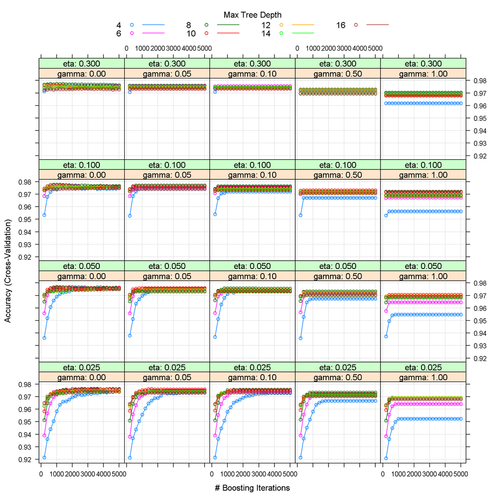

```r
plot(xgb.fit.unadj)
```

```r
TuneP<-xgb.fit.unadj$bestTune
TuneP
```

```
##      nrounds max_depth eta gamma colsample_bytree min_child_weight
## 2005    1000         8 0.1     0                1                1
##      subsample
## 2005         1
```

In addition we state the amount of times the modelled prediction deviates from the response on the training data in percent, where 1 means 100% wrong predictions and 0 100% correct predictions. Here the model always predicts the right choice, but this could also be result of overfitting and is alone more or less meaningless.

```r
fiterror<-1-mean(predict(xgb.fit.unadj,newdata=Data_unadj,na.action=na.pass)==Data_unadj$TRIGGER)
fiterror
```

```
## [1] 0
```

Instead we will look at the 10-fold crossvalidation error, which is basically 1 minus the best crossvalidation result we have seen in the plot above.

```r
cverror<-1-max(xgb.fit.unadj$results$Accuracy)
cverror
```

```
## [1] 0.02223088
```

As help to interpret the model the following plot states how import each variable was to come up with the final prediction. We will see later that the high importance of the variables Latitude and Longitude is no surprise and in fact make a lot of sense.

[output not shown]

In addition one can see that the STATUS variable contributed almost nothing to the model, thus we will remove them later on.

## Exploratory Data Analysis

In this section we take a closer look at the Data and try to find a way to improve results by visualizing relationships between our variables.

First we plot the hurricane trajectories on a map and colour whether the hurricane was triggered or not.

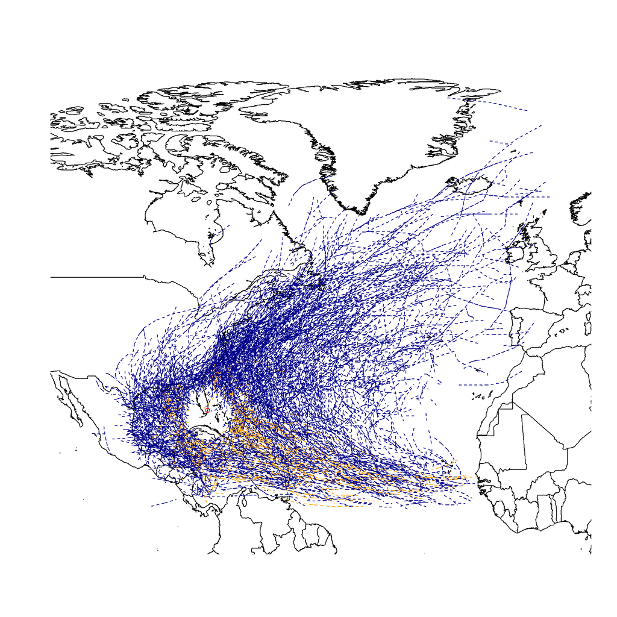

```r
maxLat<-max(dfTrain$LAT)+5
minLat<-min(dfTrain$LAT)-5

maxLon<-max(-dfTrain$LON)+5
minLon<-min(-dfTrain$LON)-5

mLat<-cbind(dfTrain$LAT,dfTrain$LAT1,dfTrain$LAT2)
mLon<-cbind(dfTrain$LON,dfTrain$LON1,dfTrain$LON2)

colour<-ifelse(dfTrain$TRIGGER==TRUE,"orange","darkblue")
colour2<-rep(colour,times=3)
newmap <- getMap(resolution = "high")
plot(newmap, xlim = c(minLon, maxLon), ylim = c(minLat, maxLat), asp = 0)

points(x=-MiamiLon, y=MiamiLat, col = "red", cex = 1)
matlines(-t(mLon),t(mLat),lty=2,col=colour2,cex = .1)
```

The trajectories in orange were the triggered ones.  
Let’s have a closer look.

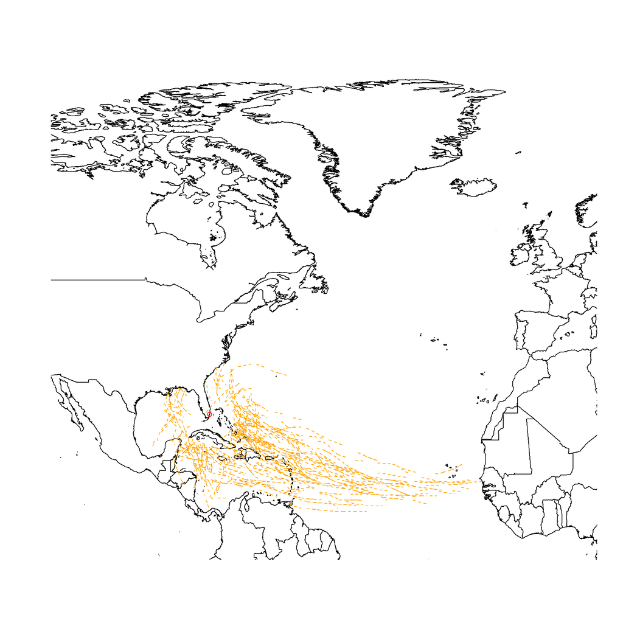

```r
mLat2<-mLat[dfTrain$TRIGGER==TRUE,]
mLon2<-mLon[dfTrain$TRIGGER==TRUE,]
plot(newmap, xlim = c(minLon, maxLon), ylim = c(minLat, maxLat), asp = 0)

points(x=-MiamiLon, y=MiamiLat, col = "red", cex = 1)
matlines(-t(mLon2),t(mLat2),lty=2,col="orange",cex = .1)
```

It is easy to see that that the hurricanes mostly start at the West African coast and are located in the lower quarter of the map. This confirms that both variables LAT and LON are important predictors for our model. But as seen in the previous plot and the importance plots other variables such as WSPD influence the result as well, which make sense if one considers how the trigger is defined. Next we will have look at the distribution of our numeric variables and see if they differ in dependence on the response variable TRIGGER.

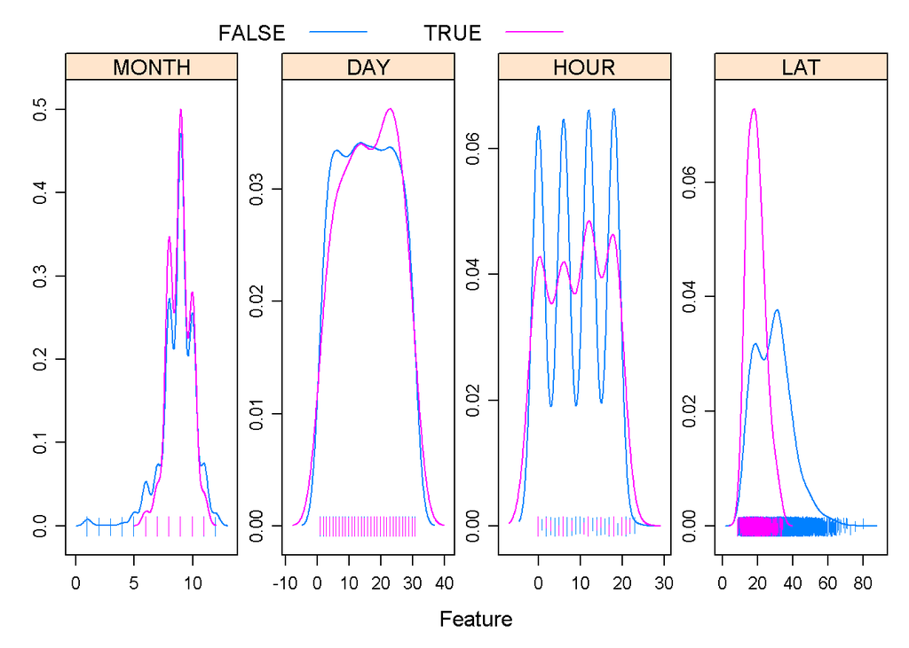

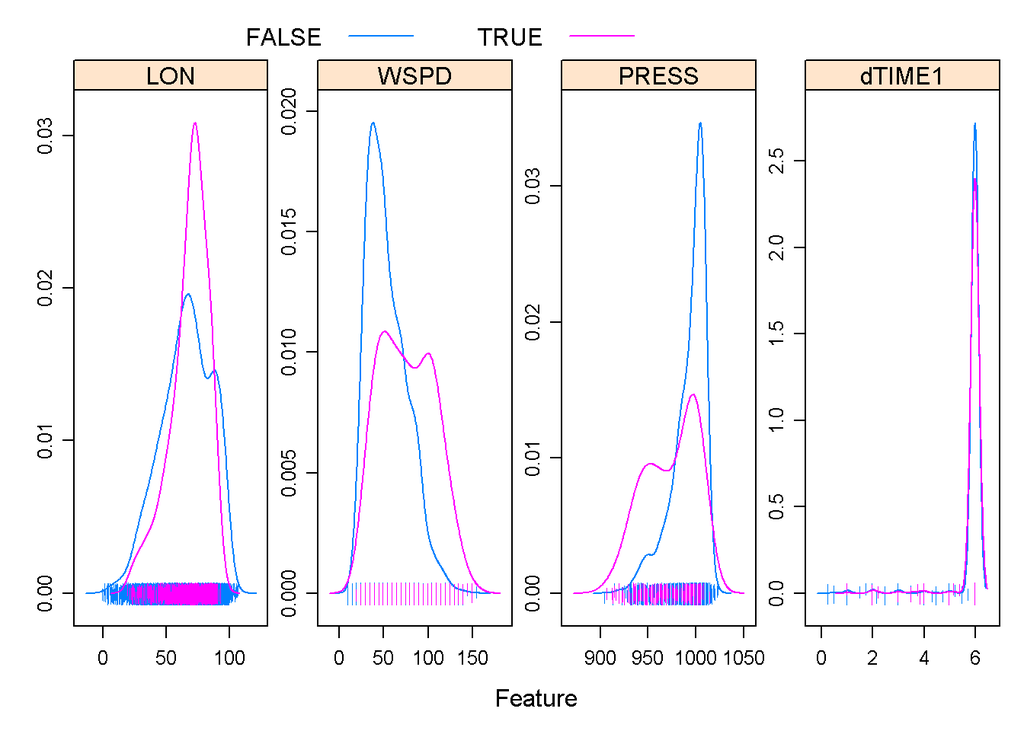

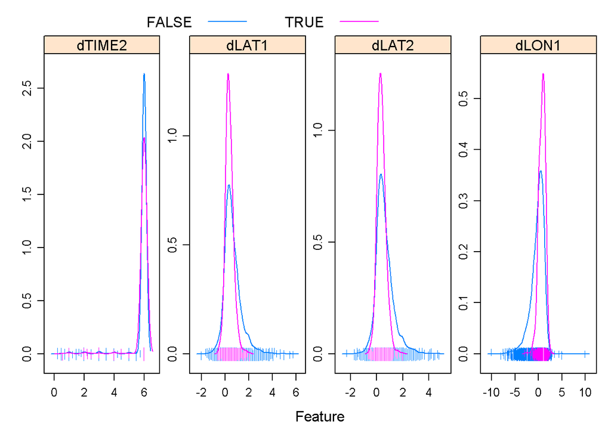

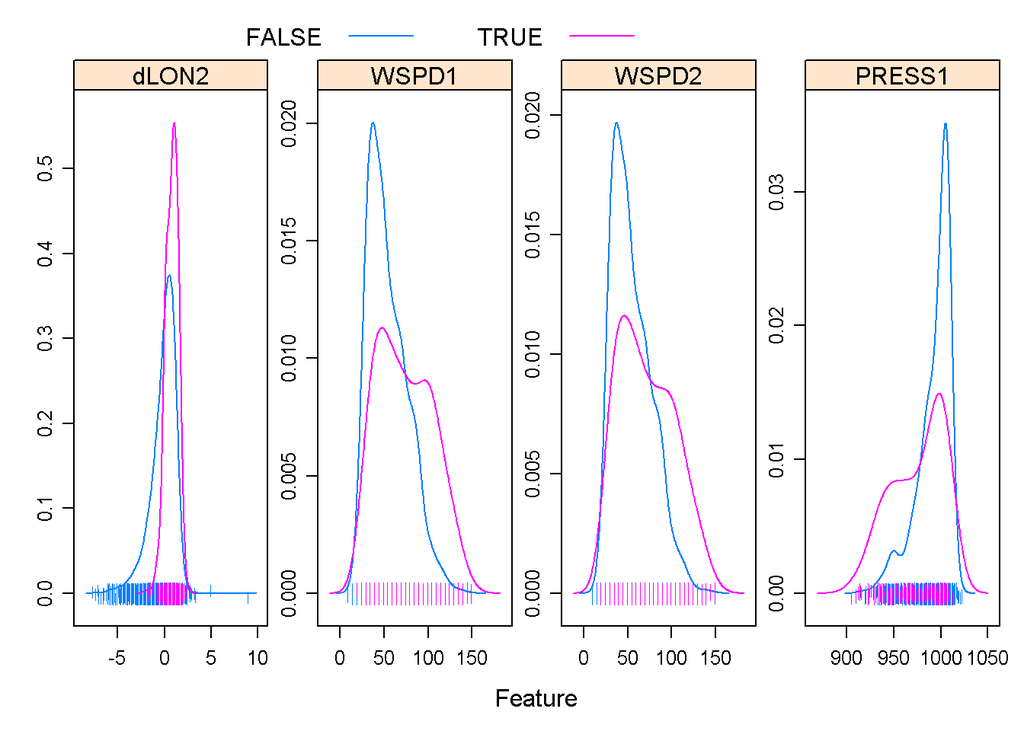

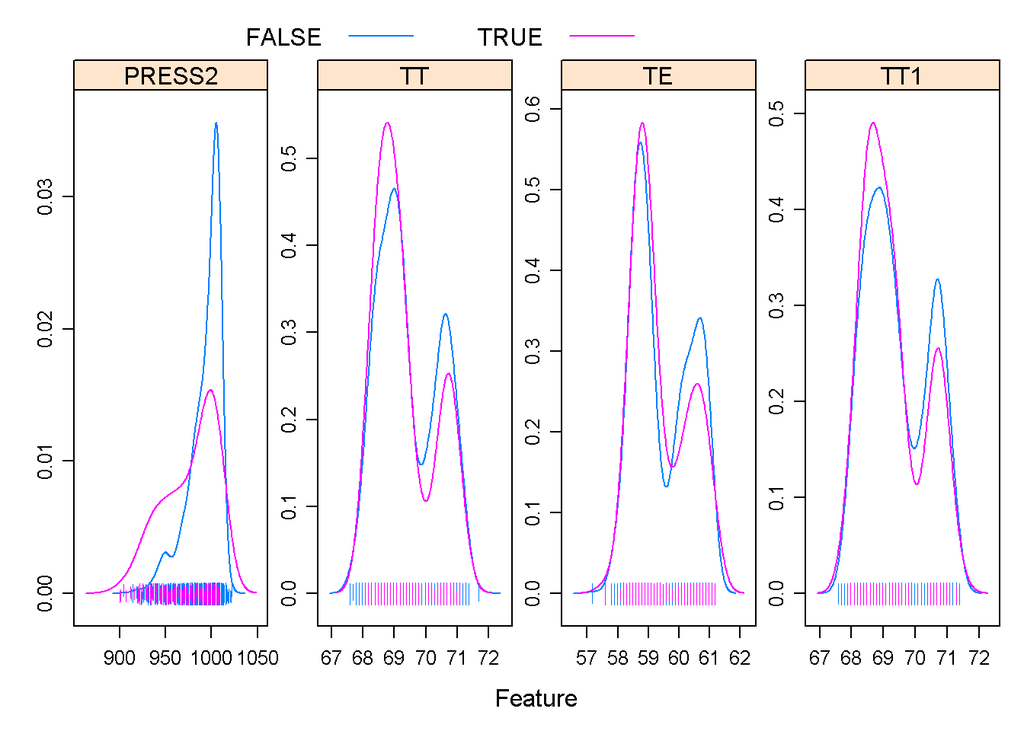

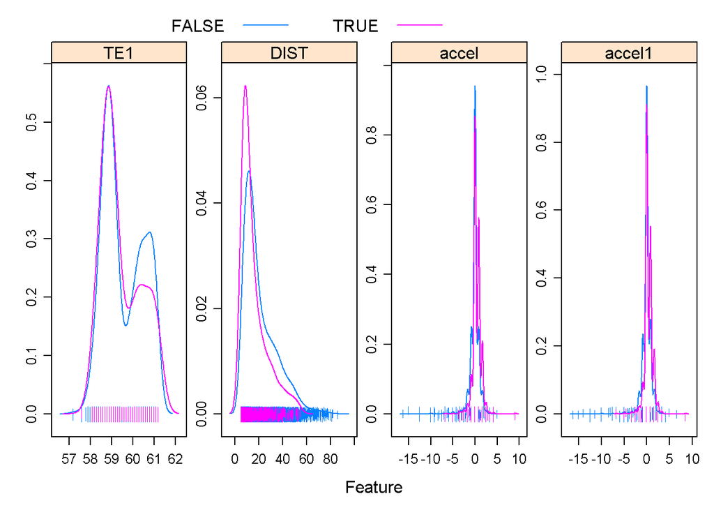

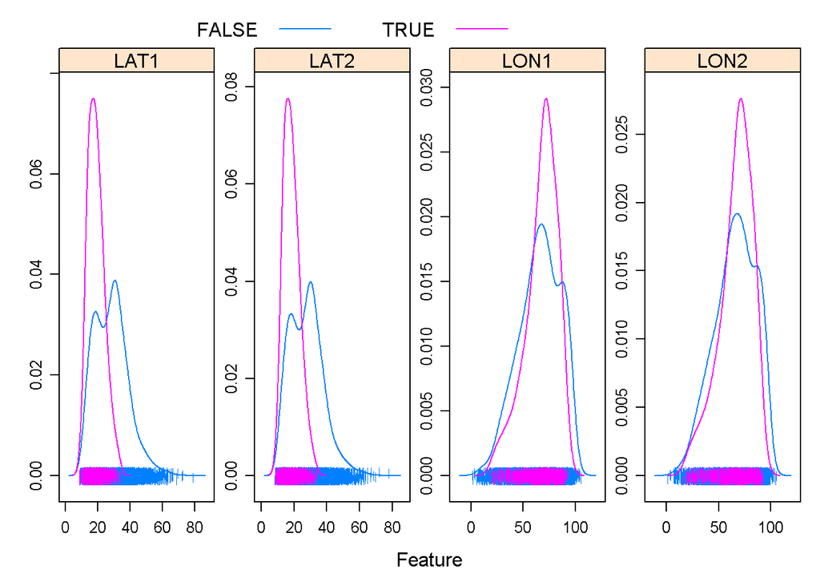

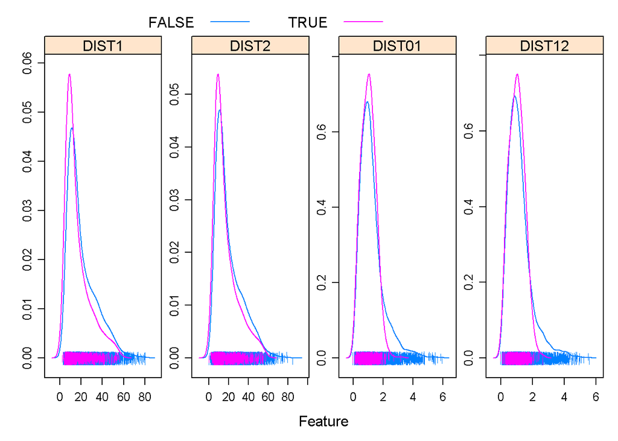

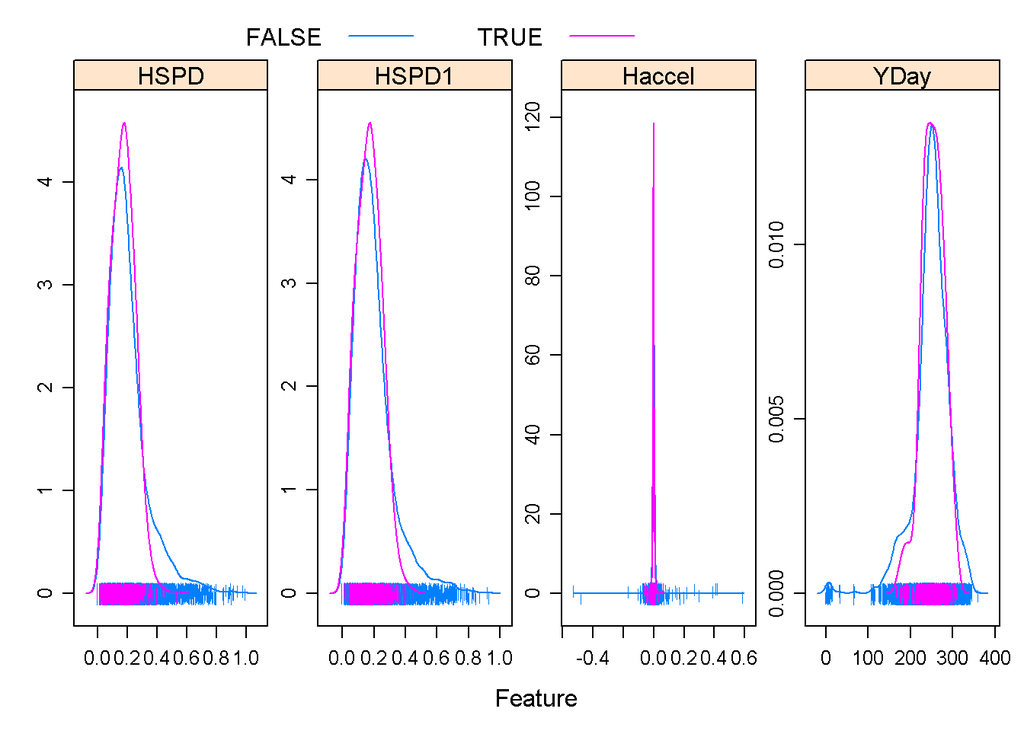

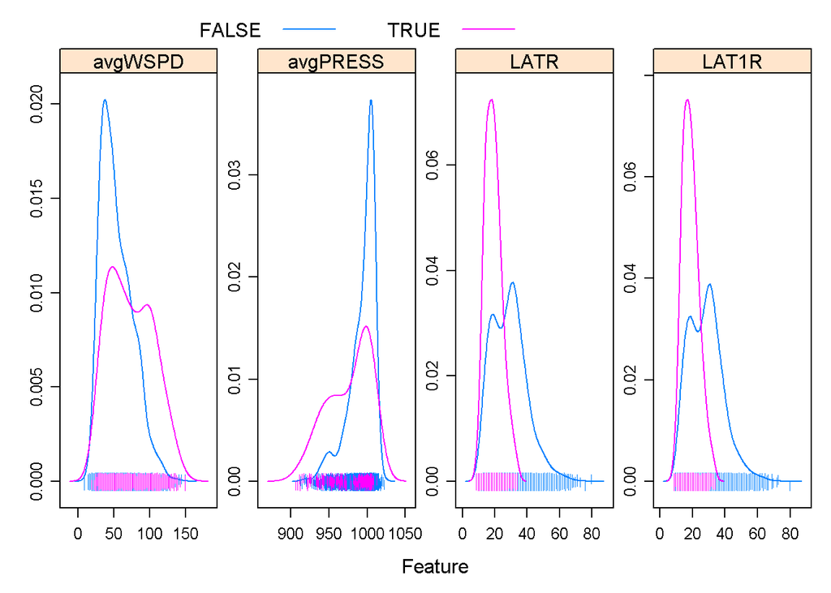

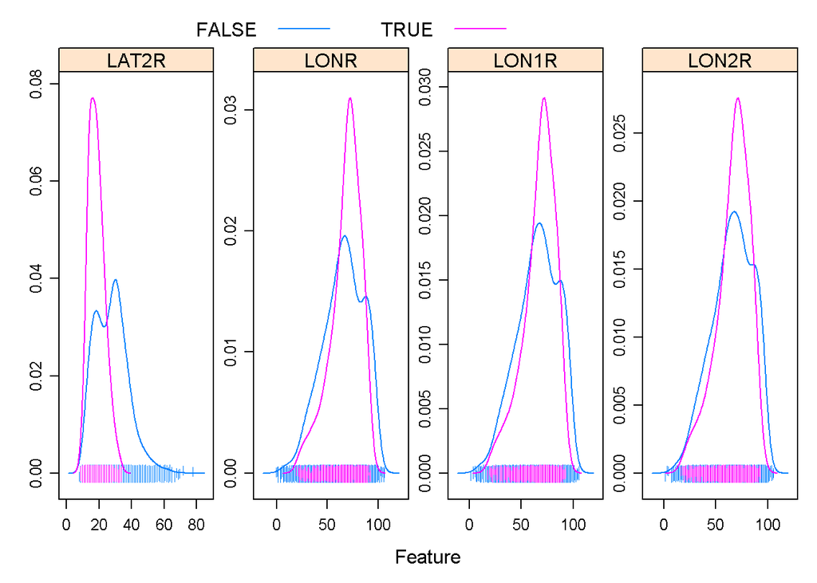

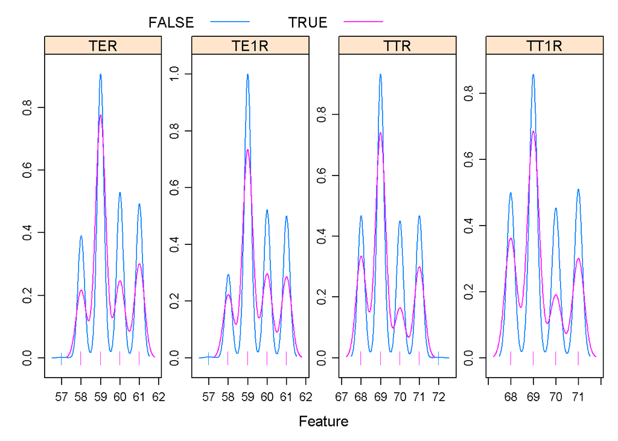

[3 more figures not shown]

```r
ind<-sapply(dfTrain,is.numeric)
ind[c(25:30,32:34)]<-FALSE
featurePlot(x = dfTrain[,ind],
            y = dfTrain$TRIGGER,
            plot = "density",
            ## Pass in options to xyplot() to
            ## make it prettier
            scales = list(x = list(relation="free"),
                          y = list(relation="free")),
            adjust = 1.5,
            pch = "|",
            layout = c(4, 1),
            auto.key = list(columns = 3))
```

Again we can see the strong correlation between the geographical location and TRIGGER, but also for wind speed (WPSD), pressure (PRESS) and the mean sea surface temperatures (TE&TT) a clear distinction between the triggered and non-triggered distribution is visible. For other variables like the Time measurements this is not the case and we will disregard them

Having to many variables in a model may be counterproductive so we take a closer look at correlation in between our variables and decide to remove high correlated ones.

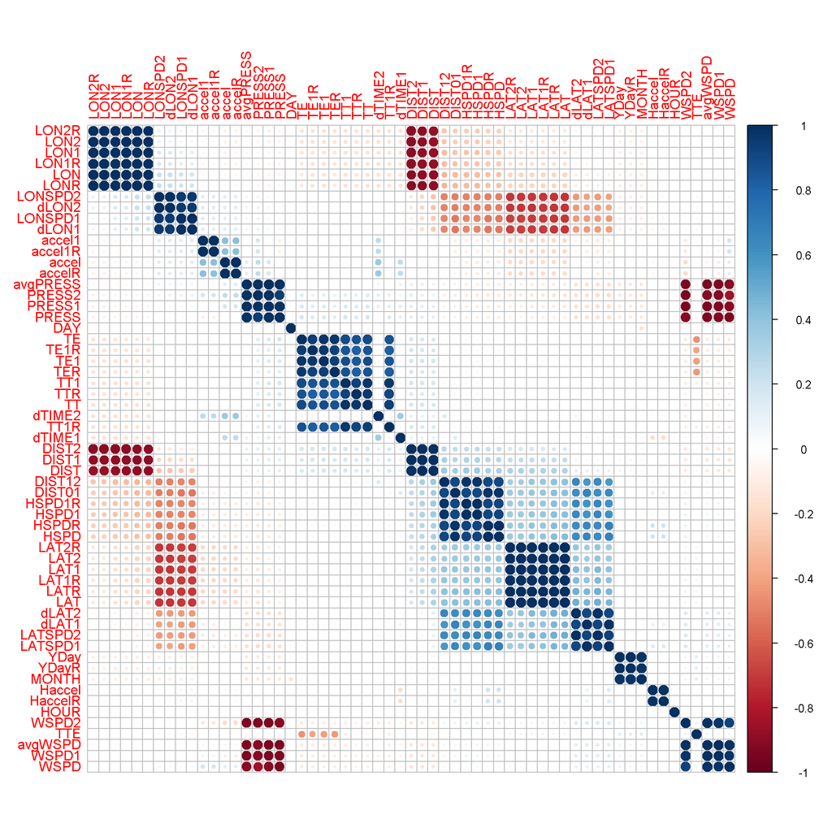

```r
M2<-cor(dfTrain[,ind],use="pairwise.complete.obs")
corrplot(M2, method = "circle", order = "AOE")
```

```r
Data_adj30<-dfTrain[,c(7:8,21:24,35,49,50,52,56:59,62)]
xgb.fit.adj30<-xgbfit(Data_adj30,control,xgb_grid.unadj,70)
```

```
## [1] "Start:"
## [1] "2019-08-27 23:06:32"
## [1] "End:"
## [1] "2019-08-27 23:54:20"
```

As for the basic model we show again the same plots.

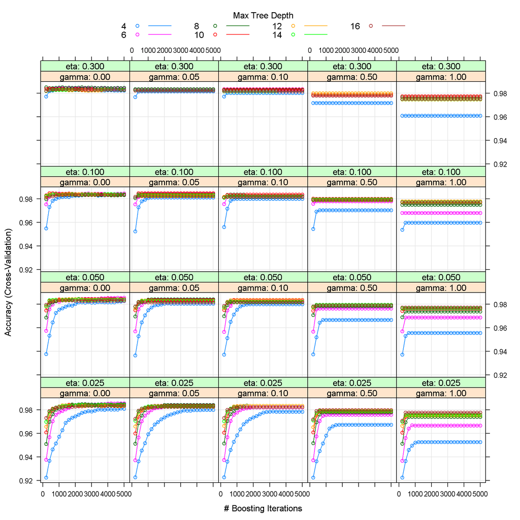

```r
plot(xgb.fit.adj30)
```

```r
xgb.fit.adj30$bestTune
```

```
##     nrounds max_depth   eta gamma colsample_bytree min_child_weight
## 149    4800         6 0.025     0                1                1
##     subsample
## 149         1
```

the training error

```r
fiterrorf<-1-mean(predict(xgb.fit.adj30,newdata=Data_adj30,na.action=na.pass)==Data_adj30$TRIGGER)
fiterrorf
```

```
## [1] 0
```

the 10 fold crossvalidation error, which improved by about 0.8 percent points

```r
cverrorf<-1-max(xgb.fit.adj30$results$Accuracy)
cverrorf
```

```
## [1] 0.01446714
```

and the importance plot:

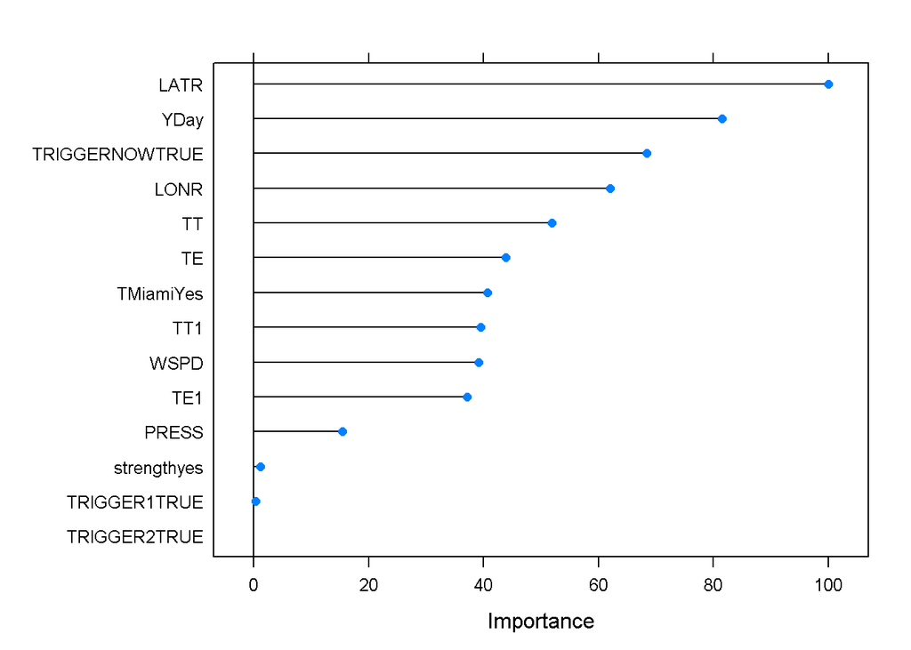

```r
xgbImp.adj30<-varImp(xgb.fit.adj30)
plot(xgbImp.adj30)
```

We can see that the variables TRIGGER1, TRIGGER2 and strength have low impact in comparison to the other variables, but they still increase accuracy and are thus part of the final model.

Additionally the correlation plot for the final Data used:

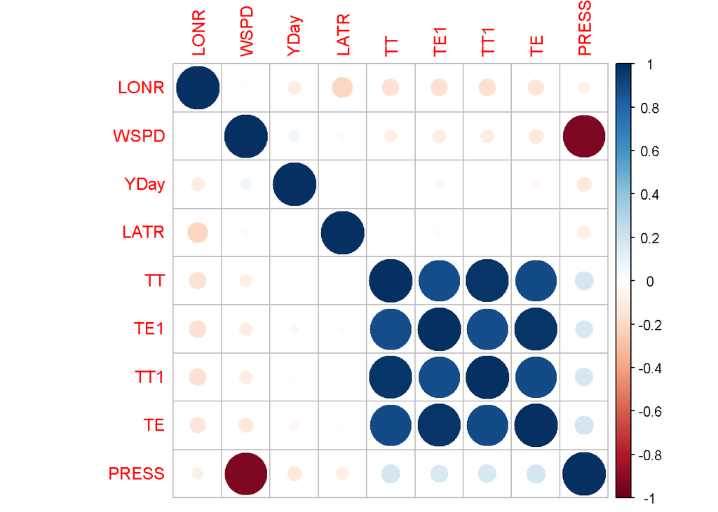

```r
ind2<-sapply(Data_adj30,is.numeric)
M3<-cor(Data_adj30[,ind2],use="pairwise.complete.obs")
corrplot(M3, method = "circle", order = "AOE")
```

One can still see some high correlations between the mean sea surface temperature variables and strong negative correlation between windspeed and pressure, but removing them would lead to an decreased crossvalidation accuracy. As we did not find any new less correlated variables to extract their meaning. This is a point were the model still could be improved given more time.

The final model does not only give a prediction whether a given hurricane from the test data will trigger the cat bond, it also give the probability of triggering the cat-bond. Together with the attached bond-prices we can use that and calculate an expected value for the profit. The decision to buy or not can then be reduced to finding positive expected profits. In contrast to buying the bonds which do not trigger the expected profit approach implements the bond prices into the decision making. For example it does not make any sense to buy a bond for the price of 1000 as no matter what happens by construction of the payout one cannot make any profit. Also bonds with high risk of triggering the cat bond but very low prices might still be worth buying, since the profit in the case of not triggering is very high. In the following piece of code we predict the probabilities for the test data , calculate the expected profit and generate the recommendation vector.

```r
pred<-predict(xgb.fit.adj30,newdata=dfTestQ,type="prob",na.action=na.pass)
EL<-(1000-dfTestQ$PRICE)*pred[,1]-dfTestQ$PRICE*pred[,2]
Buy<-EL>0
summary(Buy)
```

```
##    Mode   FALSE    TRUE
## logical    2667    1641
```

```r
save(Buy, file="Buy.RData")
save(EL, file="EL.RData")
```

Here is the total expected profit if we would only buy the bonds for which the model predicts that the hurricane will not trigger the bond.

```r
T<-predict(xgb.fit.adj30,newdata=dfTestQ,type="raw",na.action=na.pass)
T2<-ifelse(T==FALSE,1,0)
summary(as.factor(T2))
```

```
##    0    1
##  173 4135
```

```r
sum(EL*T2)
```

```
## [1] 129983
```

There are more than 2000 bonds with a price of 1000 for those it does not make any sense at all to buy.

```r
summary(dfTestQ$PRICE==1000)
```

```
##    Mode   FALSE    TRUE
## logical    2031    2277
```

Here in comparison the total expected profit by the expected profit approach:

```r
sum(EL*Buy)
```

```
## [1] 155574.2
```